# Risk Factor Analysis

## Outcome Variable

**Outcome Variable:** ever_wasted

## Predictor Variables

**Intervention Variable:** nhh

**Adjustment Set:**

unadjusted

## Stratifying Variables

The analysis was stratified on these variable(s):

- agecat
- studyid
- country

## Data Summary

| agecat | studyid | country | nhh | ever_wasted | n_cell | n |
| --- | --- | --- | --- | --- | --- | --- |
| 0-24 months | ki1000108-IRC | INDIA | 3 or less | 0 | 20 | 410 |
| 0-24 months | ki1000108-IRC | INDIA | 3 or less | 1 | 38 | 410 |
| 0-24 months | ki1000108-IRC | INDIA | 4-5 | 0 | 63 | 410 |
| 0-24 months | ki1000108-IRC | INDIA | 4-5 | 1 | 95 | 410 |
| 0-24 months | ki1000108-IRC | INDIA | 6-7 | 0 | 38 | 410 |
| 0-24 months | ki1000108-IRC | INDIA | 6-7 | 1 | 69 | 410 |
| 0-24 months | ki1000108-IRC | INDIA | 8+ | 0 | 20 | 410 |
| 0-24 months | ki1000108-IRC | INDIA | 8+ | 1 | 67 | 410 |
| 0-24 months | ki1000304b-SAS-FoodSuppl | INDIA | 3 or less | 0 | 4 | 106 |
| 0-24 months | ki1000304b-SAS-FoodSuppl | INDIA | 3 or less | 1 | 5 | 106 |
| 0-24 months | ki1000304b-SAS-FoodSuppl | INDIA | 4-5 | 0 | 19 | 106 |
| 0-24 months | ki1000304b-SAS-FoodSuppl | INDIA | 4-5 | 1 | 22 | 106 |
| 0-24 months | ki1000304b-SAS-FoodSuppl | INDIA | 6-7 | 0 | 20 | 106 |
| 0-24 months | ki1000304b-SAS-FoodSuppl | INDIA | 6-7 | 1 | 17 | 106 |
| 0-24 months | ki1000304b-SAS-FoodSuppl | INDIA | 8+ | 0 | 10 | 106 |
| 0-24 months | ki1000304b-SAS-FoodSuppl | INDIA | 8+ | 1 | 9 | 106 |
| 0-24 months | ki1017093-NIH-Birth | BANGLADESH | 3 or less | 0 | 58 | 624 |
| 0-24 months | ki1017093-NIH-Birth | BANGLADESH | 3 or less | 1 | 57 | 624 |
| 0-24 months | ki1017093-NIH-Birth | BANGLADESH | 4-5 | 0 | 134 | 624 |
| 0-24 months | ki1017093-NIH-Birth | BANGLADESH | 4-5 | 1 | 129 | 624 |
| 0-24 months | ki1017093-NIH-Birth | BANGLADESH | 6-7 | 0 | 72 | 624 |
| 0-24 months | ki1017093-NIH-Birth | BANGLADESH | 6-7 | 1 | 69 | 624 |
| 0-24 months | ki1017093-NIH-Birth | BANGLADESH | 8+ | 0 | 62 | 624 |
| 0-24 months | ki1017093-NIH-Birth | BANGLADESH | 8+ | 1 | 43 | 624 |
| 0-24 months | ki1017093b-PROVIDE | BANGLADESH | 3 or less | 0 | 98 | 700 |
| 0-24 months | ki1017093b-PROVIDE | BANGLADESH | 3 or less | 1 | 42 | 700 |
| 0-24 months | ki1017093b-PROVIDE | BANGLADESH | 4-5 | 0 | 211 | 700 |
| 0-24 months | ki1017093b-PROVIDE | BANGLADESH | 4-5 | 1 | 111 | 700 |
| 0-24 months | ki1017093b-PROVIDE | BANGLADESH | 6-7 | 0 | 94 | 700 |
| 0-24 months | ki1017093b-PROVIDE | BANGLADESH | 6-7 | 1 | 57 | 700 |

[output cut: 114 more lines]

The following strata were considered:

- agecat: 0-24 months, studyid: ki1000108-IRC, country: INDIA
- agecat: 0-24 months, studyid: ki1000304b-SAS-FoodSuppl, country: INDIA
- agecat: 0-24 months, studyid: ki1017093-NIH-Birth, country: BANGLADESH
- agecat: 0-24 months, studyid: ki1017093b-PROVIDE, country: BANGLADESH
- agecat: 0-24 months, studyid: ki1017093c-NIH-Crypto, country: BANGLADESH
- agecat: 0-24 months, studyid: ki1148112-LCNI-5, country: MALAWI
- agecat: 0-6 months, studyid: ki1000108-IRC, country: INDIA
- agecat: 0-6 months, studyid: ki1000304b-SAS-FoodSuppl, country: INDIA
- agecat: 0-6 months, studyid: ki1017093-NIH-Birth, country: BANGLADESH
- agecat: 0-6 months, studyid: ki1017093b-PROVIDE, country: BANGLADESH
- agecat: 0-6 months, studyid: ki1017093c-NIH-Crypto, country: BANGLADESH
- agecat: 0-6 months, studyid: ki1148112-LCNI-5, country: MALAWI
- agecat: 6-24 months, studyid: ki1000108-IRC, country: INDIA
- agecat: 6-24 months, studyid: ki1000304b-SAS-FoodSuppl, country: INDIA
- agecat: 6-24 months, studyid: ki1017093-NIH-Birth, country: BANGLADESH
- agecat: 6-24 months, studyid: ki1017093b-PROVIDE, country: BANGLADESH
- agecat: 6-24 months, studyid: ki1017093c-NIH-Crypto, country: BANGLADESH
- agecat: 6-24 months, studyid: ki1148112-LCNI-5, country: MALAWI

### Dropped Strata

Some strata were dropped due to rare outcomes:

- agecat: 0-24 months, studyid: ki1000304b-SAS-FoodSuppl, country: INDIA
- agecat: 0-6 months, studyid: ki1000304b-SAS-FoodSuppl, country: INDIA
- agecat: 0-6 months, studyid: ki1148112-LCNI-5, country: MALAWI
- agecat: 6-24 months, studyid: ki1000304b-SAS-FoodSuppl, country: INDIA

## Methods Detail

We’re interested in the causal parameters $E[Y_a]$ for all values of $a \in \mathcal{A}$. These parameters represent the mean outcome if, possibly contrary to fact, we intervened to set all units to have $A=a$. Under the randomization and positivity assumptions, these are identified by the statistical parameters $\psi_a=E_W[E_{Y|A,W}(Y|A=a,W)]$. In addition, we’re interested in the mean of $Y$, $E[Y]$ under no intervention (the observed mean). We will estimate these parameters by using SuperLearner to fit the relevant likelihood factors – $E_{Y|A,W}(Y|A=a,W)$ and $p(A=a|W)$, and then updating our likelihood fit using a joint TMLE.

For unadjusted analyses ($W=\{\}$), initial likelihoods were estimated using Lrnr_glm to estimate the simple $E(Y|A)$ and Lrnr_mean to estimate $p(A)$. For adjusted analyses, a small library containing Lrnr_glmnet, Lrnr_xgboost, and Lrnr_mean was used.

Having estimated these parameters, we will then use the delta method to estimate relative risks and attributable risks relative to a prespecified baseline level of $A$.

# Results Detail

## Results Plots

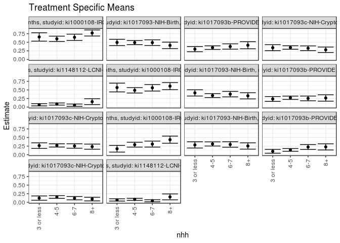

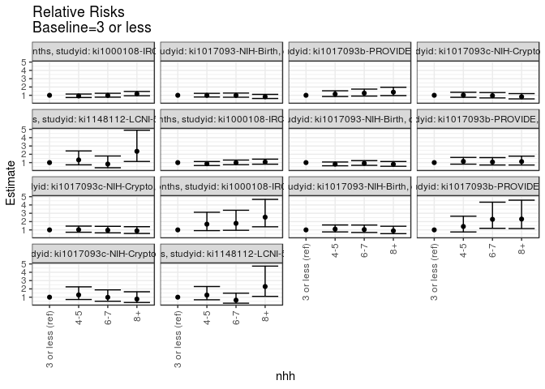

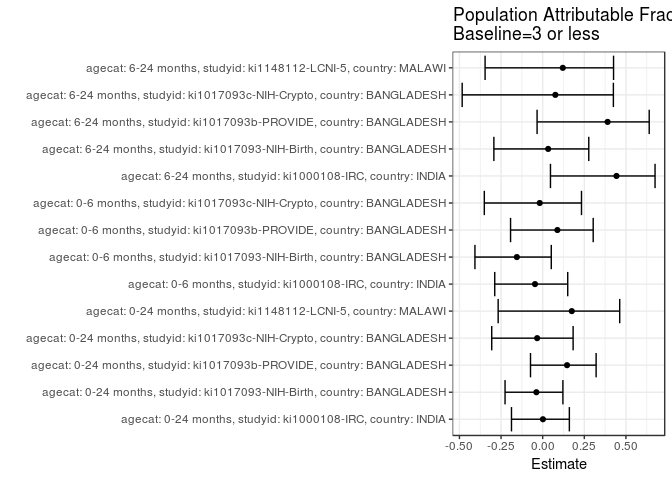

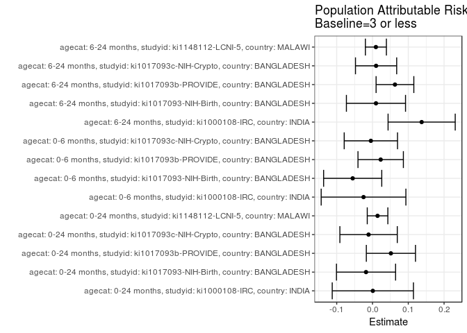

## Results Table

### Parameter: TSM

| agecat | studyid | country | intervention_level | baseline_level | estimate | ci_lower | ci_upper |
| --- | --- | --- | --- | --- | --- | --- | --- |
| 0-24 months | ki1000108-IRC | INDIA | 3 or less | NA | 0.6551724 | 0.5326986 | 0.7776462 |
| 0-24 months | ki1000108-IRC | INDIA | 4-5 | NA | 0.6012658 | 0.5248251 | 0.6777066 |
| 0-24 months | ki1000108-IRC | INDIA | 6-7 | NA | 0.6448598 | 0.5540738 | 0.7356458 |
| 0-24 months | ki1000108-IRC | INDIA | 8+ | NA | 0.7701149 | 0.6815928 | 0.8586371 |
| 0-24 months | ki1017093-NIH-Birth | BANGLADESH | 3 or less | NA | 0.4956522 | 0.4041985 | 0.5871058 |
| 0-24 months | ki1017093-NIH-Birth | BANGLADESH | 4-5 | NA | 0.4904943 | 0.4300285 | 0.5509601 |
| 0-24 months | ki1017093-NIH-Birth | BANGLADESH | 6-7 | NA | 0.4893617 | 0.4067848 | 0.5719386 |
| 0-24 months | ki1017093-NIH-Birth | BANGLADESH | 8+ | NA | 0.4095238 | 0.3153907 | 0.5036569 |
| 0-24 months | ki1017093b-PROVIDE | BANGLADESH | 3 or less | NA | 0.3000000 | 0.2240366 | 0.3759634 |
| 0-24 months | ki1017093b-PROVIDE | BANGLADESH | 4-5 | NA | 0.3447205 | 0.2927715 | 0.3966695 |
| 0-24 months | ki1017093b-PROVIDE | BANGLADESH | 6-7 | NA | 0.3774834 | 0.3001095 | 0.4548573 |
| 0-24 months | ki1017093b-PROVIDE | BANGLADESH | 8+ | NA | 0.4137931 | 0.3102274 | 0.5173588 |
| 0-24 months | ki1017093c-NIH-Crypto | BANGLADESH | 3 or less | NA | 0.3421053 | 0.2549607 | 0.4292498 |
| 0-24 months | ki1017093c-NIH-Crypto | BANGLADESH | 4-5 | NA | 0.3479532 | 0.2974381 | 0.3984684 |
| 0-24 months | ki1017093c-NIH-Crypto | BANGLADESH | 6-7 | NA | 0.3258427 | 0.2569443 | 0.3947411 |
| 0-24 months | ki1017093c-NIH-Crypto | BANGLADESH | 8+ | NA | 0.2822581 | 0.2029840 | 0.3615322 |
| 0-24 months | ki1148112-LCNI-5 | MALAWI | 3 or less | NA | 0.0666667 | 0.0340533 | 0.0992800 |
| 0-24 months | ki1148112-LCNI-5 | MALAWI | 4-5 | NA | 0.0882353 | 0.0580679 | 0.1184026 |
| 0-24 months | ki1148112-LCNI-5 | MALAWI | 6-7 | NA | 0.0549451 | 0.0218189 | 0.0880712 |
| 0-24 months | ki1148112-LCNI-5 | MALAWI | 8+ | NA | 0.1571429 | 0.0718349 | 0.2424508 |
| 0-6 months | ki1000108-IRC | INDIA | 3 or less | NA | 0.5689655 | 0.4413618 | 0.6965692 |
| 0-6 months | ki1000108-IRC | INDIA | 4-5 | NA | 0.4873418 | 0.4093084 | 0.5653752 |
| 0-6 months | ki1000108-IRC | INDIA | 6-7 | NA | 0.5607477 | 0.4665962 | 0.6548992 |
| 0-6 months | ki1000108-IRC | INDIA | 8+ | NA | 0.6091954 | 0.5065412 | 0.7118496 |
| 0-6 months | ki1017093-NIH-Birth | BANGLADESH | 3 or less | NA | 0.4122807 | 0.3218478 | 0.5027136 |
| 0-6 months | ki1017093-NIH-Birth | BANGLADESH | 4-5 | NA | 0.3346008 | 0.2775286 | 0.3916729 |
| 0-6 months | ki1017093-NIH-Birth | BANGLADESH | 6-7 | NA | 0.3758865 | 0.2958758 | 0.4558972 |
| 0-6 months | ki1017093-NIH-Birth | BANGLADESH | 8+ | NA | 0.3269231 | 0.2366962 | 0.4171500 |
| 0-6 months | ki1017093b-PROVIDE | BANGLADESH | 3 or less | NA | 0.2357143 | 0.1653560 | 0.3060726 |
| 0-6 months | ki1017093b-PROVIDE | BANGLADESH | 4-5 | NA | 0.2701863 | 0.2216499 | 0.3187228 |
| 0-6 months | ki1017093b-PROVIDE | BANGLADESH | 6-7 | NA | 0.2516556 | 0.1823890 | 0.3209223 |
| 0-6 months | ki1017093b-PROVIDE | BANGLADESH | 8+ | NA | 0.2643678 | 0.1716350 | 0.3571007 |
| 0-6 months | ki1017093c-NIH-Crypto | BANGLADESH | 3 or less | NA | 0.2631579 | 0.1822711 | 0.3440447 |
| 0-6 months | ki1017093c-NIH-Crypto | BANGLADESH | 4-5 | NA | 0.2690058 | 0.2219775 | 0.3160342 |
| 0-6 months | ki1017093c-NIH-Crypto | BANGLADESH | 6-7 | NA | 0.2528090 | 0.1889184 | 0.3166996 |
| 0-6 months | ki1017093c-NIH-Crypto | BANGLADESH | 8+ | NA | 0.2338710 | 0.1593183 | 0.3084236 |
| 6-24 months | ki1000108-IRC | INDIA | 3 or less | NA | 0.1724138 | 0.0750815 | 0.2697461 |
| 6-24 months | ki1000108-IRC | INDIA | 4-5 | NA | 0.2911392 | 0.2202173 | 0.3620612 |
| 6-24 months | ki1000108-IRC | INDIA | 6-7 | NA | 0.3084112 | 0.2207968 | 0.3960256 |
| 6-24 months | ki1000108-IRC | INDIA | 8+ | NA | 0.4367816 | 0.3324324 | 0.5411309 |
| 6-24 months | ki1017093-NIH-Birth | BANGLADESH | 3 or less | NA | 0.2842105 | 0.1934283 | 0.3749927 |
| 6-24 months | ki1017093-NIH-Birth | BANGLADESH | 4-5 | NA | 0.3116883 | 0.2519027 | 0.3714739 |
| 6-24 months | ki1017093-NIH-Birth | BANGLADESH | 6-7 | NA | 0.2968750 | 0.2176526 | 0.3760974 |
| 6-24 months | ki1017093-NIH-Birth | BANGLADESH | 8+ | NA | 0.2528736 | 0.1614540 | 0.3442931 |
| 6-24 months | ki1017093b-PROVIDE | BANGLADESH | 3 or less | NA | 0.0982143 | 0.0430534 | 0.1533752 |
| 6-24 months | ki1017093b-PROVIDE | BANGLADESH | 4-5 | NA | 0.1384083 | 0.0985623 | 0.1782543 |
| 6-24 months | ki1017093b-PROVIDE | BANGLADESH | 6-7 | NA | 0.2230769 | 0.1514550 | 0.2946989 |
| 6-24 months | ki1017093b-PROVIDE | BANGLADESH | 8+ | NA | 0.2261905 | 0.1366507 | 0.3157303 |
| 6-24 months | ki1017093c-NIH-Crypto | BANGLADESH | 3 or less | NA | 0.1214953 | 0.0595504 | 0.1834402 |
| 6-24 months | ki1017093c-NIH-Crypto | BANGLADESH | 4-5 | NA | 0.1545455 | 0.1155187 | 0.1935722 |
| 6-24 months | ki1017093c-NIH-Crypto | BANGLADESH | 6-7 | NA | 0.1193182 | 0.0713943 | 0.1672421 |
| 6-24 months | ki1017093c-NIH-Crypto | BANGLADESH | 8+ | NA | 0.0940171 | 0.0410975 | 0.1469367 |
| 6-24 months | ki1148112-LCNI-5 | MALAWI | 3 or less | NA | 0.0688073 | 0.0351851 | 0.1024296 |
| 6-24 months | ki1148112-LCNI-5 | MALAWI | 4-5 | NA | 0.0863095 | 0.0562642 | 0.1163549 |
| 6-24 months | ki1148112-LCNI-5 | MALAWI | 6-7 | NA | 0.0441989 | 0.0142371 | 0.0741607 |
| 6-24 months | ki1148112-LCNI-5 | MALAWI | 8+ | NA | 0.1571429 | 0.0718342 | 0.2424516 |

### Parameter: E(Y)

| agecat | studyid | country | intervention_level | baseline_level | estimate | ci_lower | ci_upper |
| --- | --- | --- | --- | --- | --- | --- | --- |
| 0-24 months | ki1000108-IRC | INDIA | NA | NA | 0.6560976 | 0.6100625 | 0.7021326 |
| 0-24 months | ki1017093-NIH-Birth | BANGLADESH | NA | NA | 0.4775641 | 0.4383415 | 0.5167867 |
| 0-24 months | ki1017093b-PROVIDE | BANGLADESH | NA | NA | 0.3514286 | 0.3160364 | 0.3868207 |
| 0-24 months | ki1017093c-NIH-Crypto | BANGLADESH | NA | NA | 0.3311346 | 0.2976093 | 0.3646598 |
| 0-24 months | ki1148112-LCNI-5 | MALAWI | NA | NA | 0.0807834 | 0.0620863 | 0.0994804 |
| 0-6 months | ki1000108-IRC | INDIA | NA | NA | 0.5439024 | 0.4956326 | 0.5921723 |
| 0-6 months | ki1017093-NIH-Birth | BANGLADESH | NA | NA | 0.3569132 | 0.3192325 | 0.3945938 |
| 0-6 months | ki1017093b-PROVIDE | BANGLADESH | NA | NA | 0.2585714 | 0.2261125 | 0.2910304 |
| 0-6 months | ki1017093c-NIH-Crypto | BANGLADESH | NA | NA | 0.2585752 | 0.2273844 | 0.2897660 |
| 6-24 months | ki1000108-IRC | INDIA | NA | NA | 0.3097561 | 0.2649438 | 0.3545684 |
| 6-24 months | ki1017093-NIH-Birth | BANGLADESH | NA | NA | 0.2939002 | 0.2554778 | 0.3323226 |
| 6-24 months | ki1017093b-PROVIDE | BANGLADESH | NA | NA | 0.1609756 | 0.1319065 | 0.1900447 |
| 6-24 months | ki1017093c-NIH-Crypto | BANGLADESH | NA | NA | 0.1315069 | 0.1069744 | 0.1560393 |
| 6-24 months | ki1148112-LCNI-5 | MALAWI | NA | NA | 0.0782609 | 0.0596958 | 0.0968259 |

### Parameter: RR

| agecat | studyid | country | intervention_level | baseline_level | estimate | ci_lower | ci_upper |
| --- | --- | --- | --- | --- | --- | --- | --- |
| 0-24 months | ki1000108-IRC | INDIA | 3 or less | 3 or less | 1.0000000 | 1.0000000 | 1.000000 |
| 0-24 months | ki1000108-IRC | INDIA | 4-5 | 3 or less | 0.9177215 | 0.7320329 | 1.150512 |
| 0-24 months | ki1000108-IRC | INDIA | 6-7 | 3 or less | 0.9842597 | 0.7788916 | 1.243777 |
| 0-24 months | ki1000108-IRC | INDIA | 8+ | 3 or less | 1.1754386 | 0.9438335 | 1.463877 |
| 0-24 months | ki1017093-NIH-Birth | BANGLADESH | 3 or less | 3 or less | 1.0000000 | 1.0000000 | 1.000000 |
| 0-24 months | ki1017093-NIH-Birth | BANGLADESH | 4-5 | 3 or less | 0.9895938 | 0.7926569 | 1.235460 |
| 0-24 months | ki1017093-NIH-Birth | BANGLADESH | 6-7 | 3 or less | 0.9873087 | 0.7688874 | 1.267778 |
| 0-24 months | ki1017093-NIH-Birth | BANGLADESH | 8+ | 3 or less | 0.8262323 | 0.6153071 | 1.109462 |
| 0-24 months | ki1017093b-PROVIDE | BANGLADESH | 3 or less | 3 or less | 1.0000000 | 1.0000000 | 1.000000 |
| 0-24 months | ki1017093b-PROVIDE | BANGLADESH | 4-5 | 3 or less | 1.1490683 | 0.8558063 | 1.542823 |
| 0-24 months | ki1017093b-PROVIDE | BANGLADESH | 6-7 | 3 or less | 1.2582781 | 0.9084354 | 1.742847 |
| 0-24 months | ki1017093b-PROVIDE | BANGLADESH | 8+ | 3 or less | 1.3793103 | 0.9661394 | 1.969174 |
| 0-24 months | ki1017093c-NIH-Crypto | BANGLADESH | 3 or less | 3 or less | 1.0000000 | 1.0000000 | 1.000000 |
| 0-24 months | ki1017093c-NIH-Crypto | BANGLADESH | 4-5 | 3 or less | 1.0170940 | 0.7586256 | 1.363624 |
| 0-24 months | ki1017093c-NIH-Crypto | BANGLADESH | 6-7 | 3 or less | 0.9524633 | 0.6840265 | 1.326244 |
| 0-24 months | ki1017093c-NIH-Crypto | BANGLADESH | 8+ | 3 or less | 0.8250620 | 0.5646979 | 1.205472 |
| 0-24 months | ki1148112-LCNI-5 | MALAWI | 3 or less | 3 or less | 1.0000000 | 1.0000000 | 1.000000 |
| 0-24 months | ki1148112-LCNI-5 | MALAWI | 4-5 | 3 or less | 1.3235294 | 0.7286720 | 2.404004 |
| 0-24 months | ki1148112-LCNI-5 | MALAWI | 6-7 | 3 or less | 0.8241758 | 0.3791687 | 1.791460 |
| 0-24 months | ki1148112-LCNI-5 | MALAWI | 8+ | 3 or less | 2.3571429 | 1.1350552 | 4.895024 |
| 0-6 months | ki1000108-IRC | INDIA | 3 or less | 3 or less | 1.0000000 | 1.0000000 | 1.000000 |
| 0-6 months | ki1000108-IRC | INDIA | 4-5 | 3 or less | 0.8565401 | 0.6502353 | 1.128301 |
| 0-6 months | ki1000108-IRC | INDIA | 6-7 | 3 or less | 0.9855565 | 0.7447478 | 1.304229 |
| 0-6 months | ki1000108-IRC | INDIA | 8+ | 3 or less | 1.0707071 | 0.8087995 | 1.417426 |
| 0-6 months | ki1017093-NIH-Birth | BANGLADESH | 3 or less | 3 or less | 1.0000000 | 1.0000000 | 1.000000 |
| 0-6 months | ki1017093-NIH-Birth | BANGLADESH | 4-5 | 3 or less | 0.8115848 | 0.6146958 | 1.071538 |
| 0-6 months | ki1017093-NIH-Birth | BANGLADESH | 6-7 | 3 or less | 0.9117248 | 0.6716165 | 1.237674 |
| 0-6 months | ki1017093-NIH-Birth | BANGLADESH | 8+ | 3 or less | 0.7929624 | 0.5573748 | 1.128127 |
| 0-6 months | ki1017093b-PROVIDE | BANGLADESH | 3 or less | 3 or less | 1.0000000 | 1.0000000 | 1.000000 |
| 0-6 months | ki1017093b-PROVIDE | BANGLADESH | 4-5 | 3 or less | 1.1462451 | 0.8090568 | 1.623962 |
| 0-6 months | ki1017093b-PROVIDE | BANGLADESH | 6-7 | 3 or less | 1.0676299 | 0.7113558 | 1.602340 |
| 0-6 months | ki1017093b-PROVIDE | BANGLADESH | 8+ | 3 or less | 1.1215604 | 0.7076098 | 1.777672 |
| 0-6 months | ki1017093c-NIH-Crypto | BANGLADESH | 3 or less | 3 or less | 1.0000000 | 1.0000000 | 1.000000 |
| 0-6 months | ki1017093c-NIH-Crypto | BANGLADESH | 4-5 | 3 or less | 1.0222222 | 0.7177529 | 1.455847 |
| 0-6 months | ki1017093c-NIH-Crypto | BANGLADESH | 6-7 | 3 or less | 0.9606742 | 0.6452962 | 1.430188 |
| 0-6 months | ki1017093c-NIH-Crypto | BANGLADESH | 8+ | 3 or less | 0.8887097 | 0.5707462 | 1.383811 |
| 6-24 months | ki1000108-IRC | INDIA | 3 or less | 3 or less | 1.0000000 | 1.0000000 | 1.000000 |
| 6-24 months | ki1000108-IRC | INDIA | 4-5 | 3 or less | 1.6886076 | 0.9130730 | 3.122856 |
| 6-24 months | ki1000108-IRC | INDIA | 6-7 | 3 or less | 1.7887850 | 0.9508111 | 3.365287 |
| 6-24 months | ki1000108-IRC | INDIA | 8+ | 3 or less | 2.5333333 | 1.3723682 | 4.676426 |
| 6-24 months | ki1017093-NIH-Birth | BANGLADESH | 3 or less | 3 or less | 1.0000000 | 1.0000000 | 1.000000 |
| 6-24 months | ki1017093-NIH-Birth | BANGLADESH | 4-5 | 3 or less | 1.0966811 | 0.7555589 | 1.591814 |
| 6-24 months | ki1017093-NIH-Birth | BANGLADESH | 6-7 | 3 or less | 1.0445602 | 0.6889237 | 1.583784 |
| 6-24 months | ki1017093-NIH-Birth | BANGLADESH | 8+ | 3 or less | 0.8897403 | 0.5492269 | 1.441367 |
| 6-24 months | ki1017093b-PROVIDE | BANGLADESH | 3 or less | 3 or less | 1.0000000 | 1.0000000 | 1.000000 |
| 6-24 months | ki1017093b-PROVIDE | BANGLADESH | 4-5 | 3 or less | 1.4092482 | 0.7497114 | 2.648993 |
| 6-24 months | ki1017093b-PROVIDE | BANGLADESH | 6-7 | 3 or less | 2.2713286 | 1.1893821 | 4.337491 |
| 6-24 months | ki1017093b-PROVIDE | BANGLADESH | 8+ | 3 or less | 2.3030303 | 1.1584689 | 4.578412 |
| 6-24 months | ki1017093c-NIH-Crypto | BANGLADESH | 3 or less | 3 or less | 1.0000000 | 1.0000000 | 1.000000 |
| 6-24 months | ki1017093c-NIH-Crypto | BANGLADESH | 4-5 | 3 or less | 1.2720280 | 0.7201094 | 2.246958 |
| 6-24 months | ki1017093c-NIH-Crypto | BANGLADESH | 6-7 | 3 or less | 0.9820804 | 0.5131756 | 1.879439 |
| 6-24 months | ki1017093c-NIH-Crypto | BANGLADESH | 8+ | 3 or less | 0.7738330 | 0.3620921 | 1.653772 |
| 6-24 months | ki1148112-LCNI-5 | MALAWI | 3 or less | 3 or less | 1.0000000 | 1.0000000 | 1.000000 |
| 6-24 months | ki1148112-LCNI-5 | MALAWI | 4-5 | 3 or less | 1.2543651 | 0.6884364 | 2.285515 |
| 6-24 months | ki1148112-LCNI-5 | MALAWI | 6-7 | 3 or less | 0.6423573 | 0.2785228 | 1.481469 |
| 6-24 months | ki1148112-LCNI-5 | MALAWI | 8+ | 3 or less | 2.2838095 | 1.1001482 | 4.740985 |

### Parameter: PAR

| agecat | studyid | country | intervention_level | baseline_level | estimate | ci_lower | ci_upper |
| --- | --- | --- | --- | --- | --- | --- | --- |
| 0-24 months | ki1000108-IRC | INDIA | 3 or less | NA | 0.0009251 | -0.1125438 | 0.1143941 |
| 0-24 months | ki1017093-NIH-Birth | BANGLADESH | 3 or less | NA | -0.0180881 | -0.1006676 | 0.0644915 |
| 0-24 months | ki1017093b-PROVIDE | BANGLADESH | 3 or less | NA | 0.0514286 | -0.0172363 | 0.1200934 |
| 0-24 months | ki1017093c-NIH-Crypto | BANGLADESH | 3 or less | NA | -0.0109707 | -0.0911820 | 0.0692406 |
| 0-24 months | ki1148112-LCNI-5 | MALAWI | 3 or less | NA | 0.0141167 | -0.0146473 | 0.0428807 |
| 0-6 months | ki1000108-IRC | INDIA | 3 or less | NA | -0.0250631 | -0.1434095 | 0.0932833 |
| 0-6 months | ki1017093-NIH-Birth | BANGLADESH | 3 or less | NA | -0.0553675 | -0.1366090 | 0.0258740 |
| 0-6 months | ki1017093b-PROVIDE | BANGLADESH | 3 or less | NA | 0.0228571 | -0.0405760 | 0.0862902 |
| 0-6 months | ki1017093c-NIH-Crypto | BANGLADESH | 3 or less | NA | -0.0045827 | -0.0790647 | 0.0698993 |
| 6-24 months | ki1000108-IRC | INDIA | 3 or less | NA | 0.1373423 | 0.0435266 | 0.2311580 |
| 6-24 months | ki1017093-NIH-Birth | BANGLADESH | 3 or less | NA | 0.0096897 | -0.0729136 | 0.0922929 |
| 6-24 months | ki1017093b-PROVIDE | BANGLADESH | 3 or less | NA | 0.0627613 | 0.0100404 | 0.1154822 |
| 6-24 months | ki1017093c-NIH-Crypto | BANGLADESH | 3 or less | NA | 0.0100115 | -0.0475571 | 0.0675801 |
| 6-24 months | ki1148112-LCNI-5 | MALAWI | 3 or less | NA | 0.0094535 | -0.0199207 | 0.0388278 |

### Parameter: PAF

| agecat | studyid | country | intervention_level | baseline_level | estimate | ci_lower | ci_upper |
| --- | --- | --- | --- | --- | --- | --- | --- |
| 0-24 months | ki1000108-IRC | INDIA | 3 or less | NA | 0.0014101 | -0.1874147 | 0.1602076 |
| 0-24 months | ki1017093-NIH-Birth | BANGLADESH | 3 or less | NA | -0.0378757 | -0.2260628 | 0.1214268 |
| 0-24 months | ki1017093b-PROVIDE | BANGLADESH | 3 or less | NA | 0.1463415 | -0.0731627 | 0.3209484 |
| 0-24 months | ki1017093c-NIH-Crypto | BANGLADESH | 3 or less | NA | -0.0331306 | -0.3061162 | 0.1827994 |
| 0-24 months | ki1148112-LCNI-5 | MALAWI | 3 or less | NA | 0.1747475 | -0.2674509 | 0.4626682 |
| 0-6 months | ki1000108-IRC | INDIA | 3 or less | NA | -0.0460801 | -0.2880219 | 0.1504154 |
| 0-6 months | ki1017093-NIH-Birth | BANGLADESH | 3 or less | NA | -0.1551288 | -0.4069294 | 0.0516066 |
| 0-6 months | ki1017093b-PROVIDE | BANGLADESH | 3 or less | NA | 0.0883978 | -0.1929846 | 0.3034122 |
| 0-6 months | ki1017093c-NIH-Crypto | BANGLADESH | 3 or less | NA | -0.0177229 | -0.3506648 | 0.2331481 |
| 6-24 months | ki1000108-IRC | INDIA | 3 or less | NA | 0.4433885 | 0.0467691 | 0.6749829 |
| 6-24 months | ki1017093-NIH-Birth | BANGLADESH | 3 or less | NA | 0.0329692 | -0.2931866 | 0.2768649 |
| 6-24 months | ki1017093b-PROVIDE | BANGLADESH | 3 or less | NA | 0.3898809 | -0.0336624 | 0.6398773 |
| 6-24 months | ki1017093c-NIH-Crypto | BANGLADESH | 3 or less | NA | 0.0761293 | -0.4835996 | 0.4246850 |
| 6-24 months | ki1148112-LCNI-5 | MALAWI | 3 or less | NA | 0.1207951 | -0.3459615 | 0.4256884 |